# Time Series Analysis:

### Ex 1.13: Signal in Noise

Most time series are composed of an underlying signal with some constant periodic variation, and a random error (noise) term. Generally, we are presented with data that show the signal obscured by noise. The purpose of many time series models is to decompose the time series to understand the underlying trend.

```r
# A simple cosin wave
cs = 3*cos(2*pi*1:500/50 + 0.6*pi)
# Some random noise
noise = rnorm(500, 0, 1)
```

The ratio of amplitude of the signal to error is called the signal-to-noise ratio (SNR); the larger the SNR, the easier it is to detect the signal. Here, we can easily understand the signal in the second panel, but would have a hard time confidently explaining the third panel.

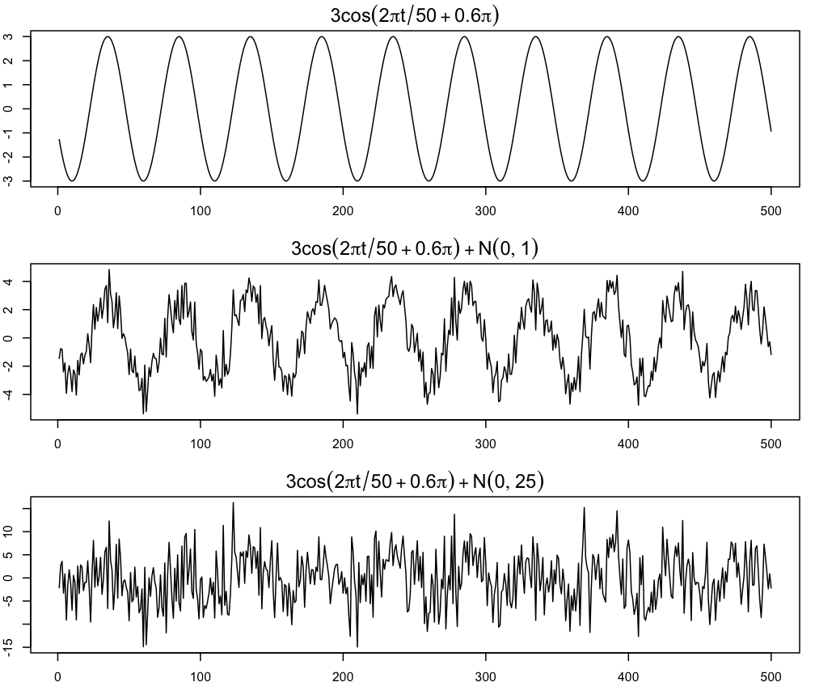

```r
par(mfrow=c(3,1), mar=c(3,2,2,1), cex.main=1.5)
plot.ts(cs, main=expression(3*cos(2*pi*t/50 + 0.6*pi)))
plot.ts(cs+noise, main=expression(3*cos(2*pi*t/50 + 0.6*pi) + N(0, 1)))
plot.ts(cs+noise*5, main=expression(3*cos(2*pi*t/50 + 0.6*pi) + N(0, 25)))
```

These simple additive models are some of the most common, and takes the form

\[xt = st + vt\]

where `st` denotes an unknown signal, and `vt` denotes a white noise or correlated error term.

### 1.2 Definitions

Since correlation is such an essential component of time series analysis, the best descriptive statistics are expressed in terms of co-variance and correlation.

## 2.0: Regression and Exploratory Data Analysis

See next chapter, here